# Time of Year Restrictions for Offshore Wind Development (OWD)

DRAFT - Results likely to change

# Approach

Habitat-based North Atlantic right whale (NARW) density models for the U.S. Atlantic were downloaded from [OBIS-SEAMAP](https://seamap.env.duke.edu/models/Duke/EC/). The monthly images were deconstructed into data tables where each row represents a single grid cell, with columns representing attributes of that grid cell (e.g., cell id, cell centroid, cell area, month, density value). We then augmented these data tables with bottom depth by extracting bathymetry values from the ETOPO 2022 15 Arc-Second Global Relief Model (bedrock elevation) at each cell centroid. Next, we performed a spatial intersection to assign every grid cell to our nested study area polygons (region > lease areas). NARWs primarily inhabit coastal waters along the U.S. eastern continental shelf, and so we excluded cells where the bottom depth was greater than 1000 meters (the outer boundary of the continental margin / slope). All spatial layers used a bespoke Albers Equal Area coordinate reference system developed by the Marine Geospatial Ecology Lab, Duke University (CetMap_NA). Below are maps of the monthly NARW density data, with superimposed white outlines that denote some of the considered areas.

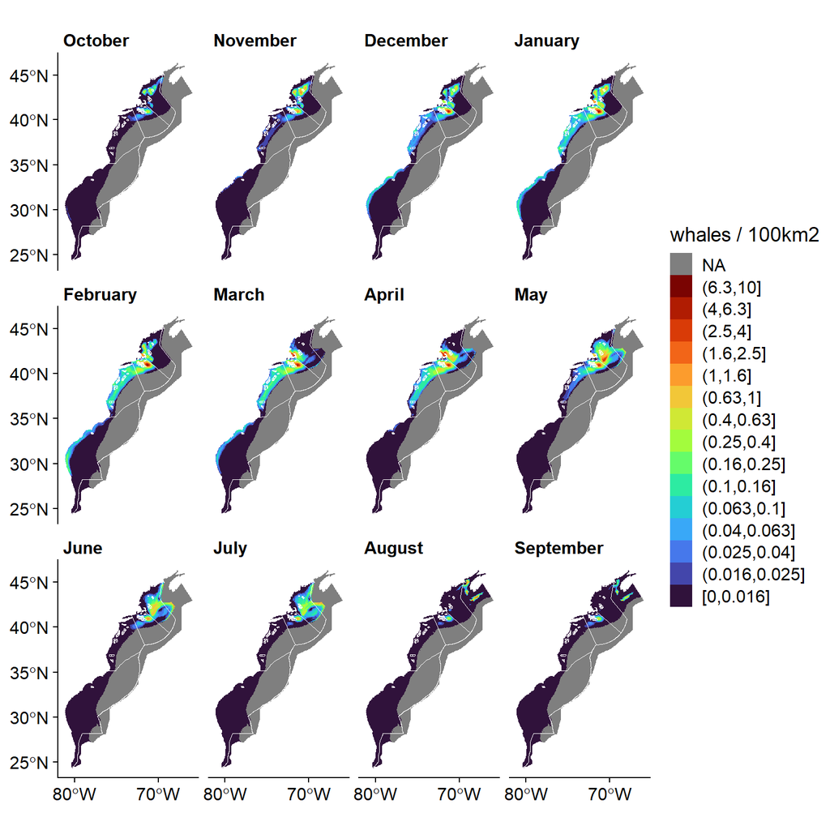

# Results

Below are boxplots of the monthly NARW densities by lease area (roughly ordered from north to south). The boxplots were drawn such that the lower whisker represents the 10th percentile, the lower hinge represents the 25th percentile, the dot represents the mean, the line represents the median, the upper hinge represents the 75th percentile, and the upper whisker represents the 90th percentile. Underneath each boxplot is a barplot that shows the habitat selection ratio for that lease area, on the natural-log scale. The habitat selection ratio, R, is calculated as the average abundance inside of a lease area over the average abundance outside of that lease area bounded by the respective region. Underneath the barplots are Gantt charts indicating months that should impose temporal restrictions on OWD using several metrics (blue bars):

1. 90th percentile
2. 75th percentile
3. 50th percentile
4. Average

For all metrics, the blue bar indicates when the monthly value exceeded the average annual density along the entire coast. As an example with the 90th percentile, the blue bar would indicate when the 90th percentile of monthly density in a lease area exceeded the average annual density. The y-axis of the Gantt charts indicates the degree that lease areas were buffered (0km = not buffered, 10km = buffered by 10km, and 40km = buffered by 40km).

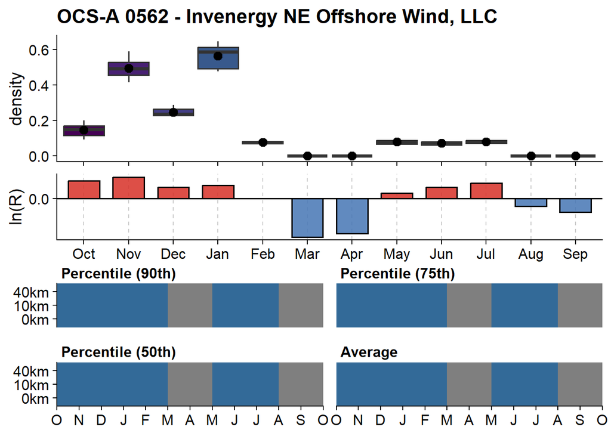

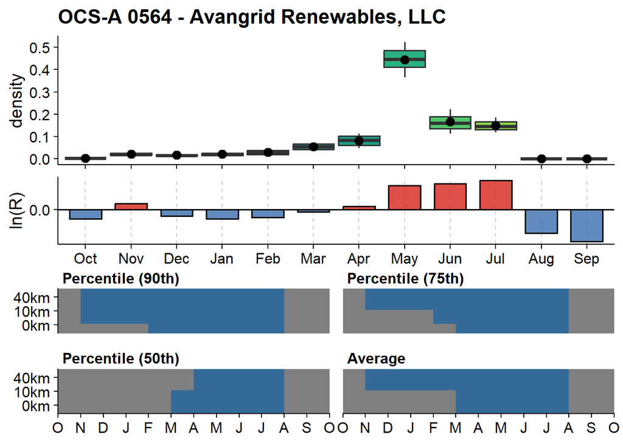

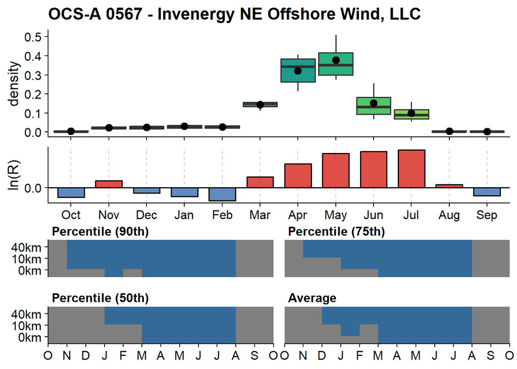

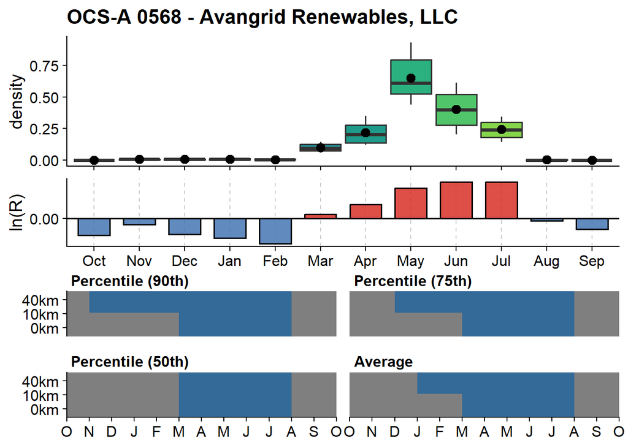

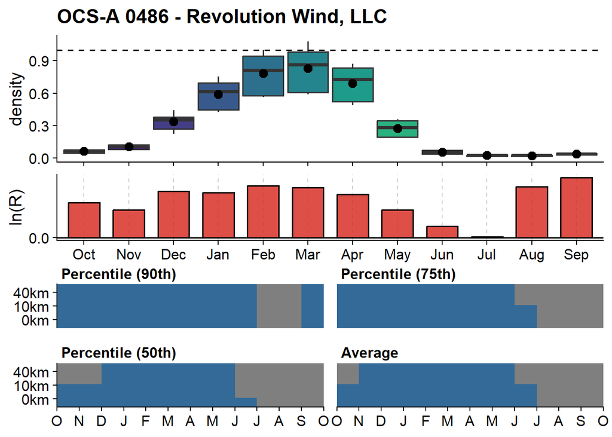

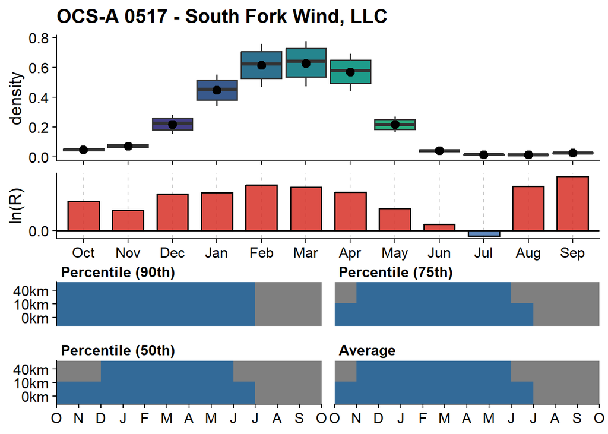

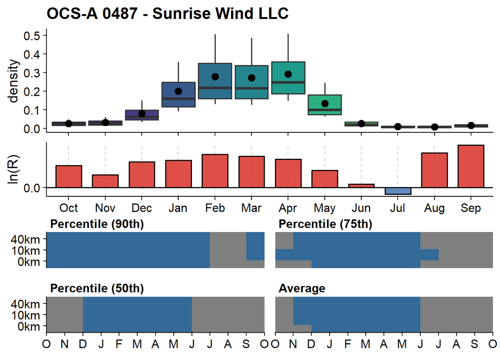

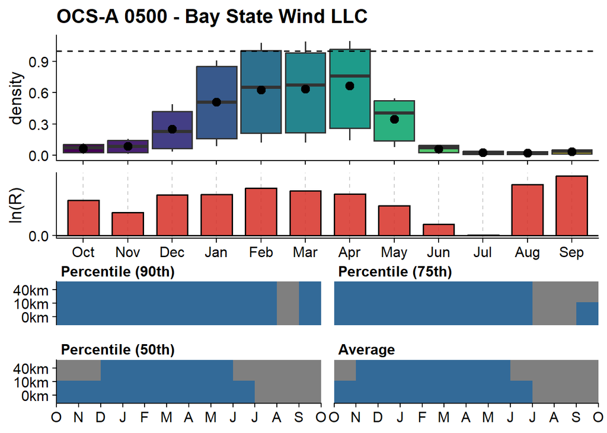

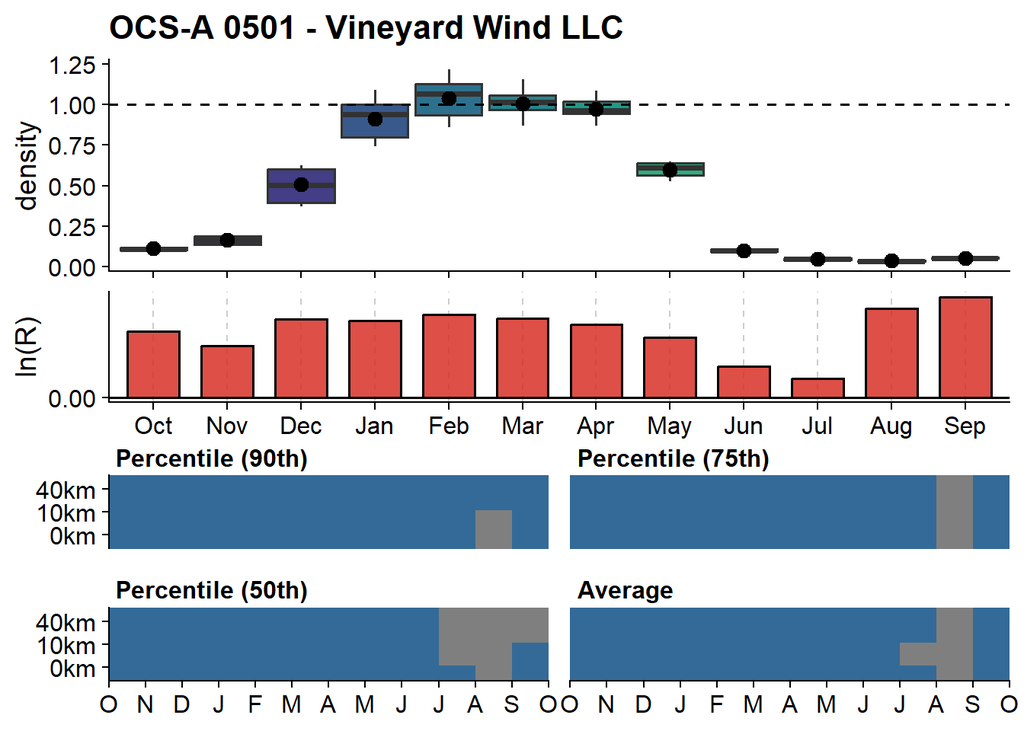

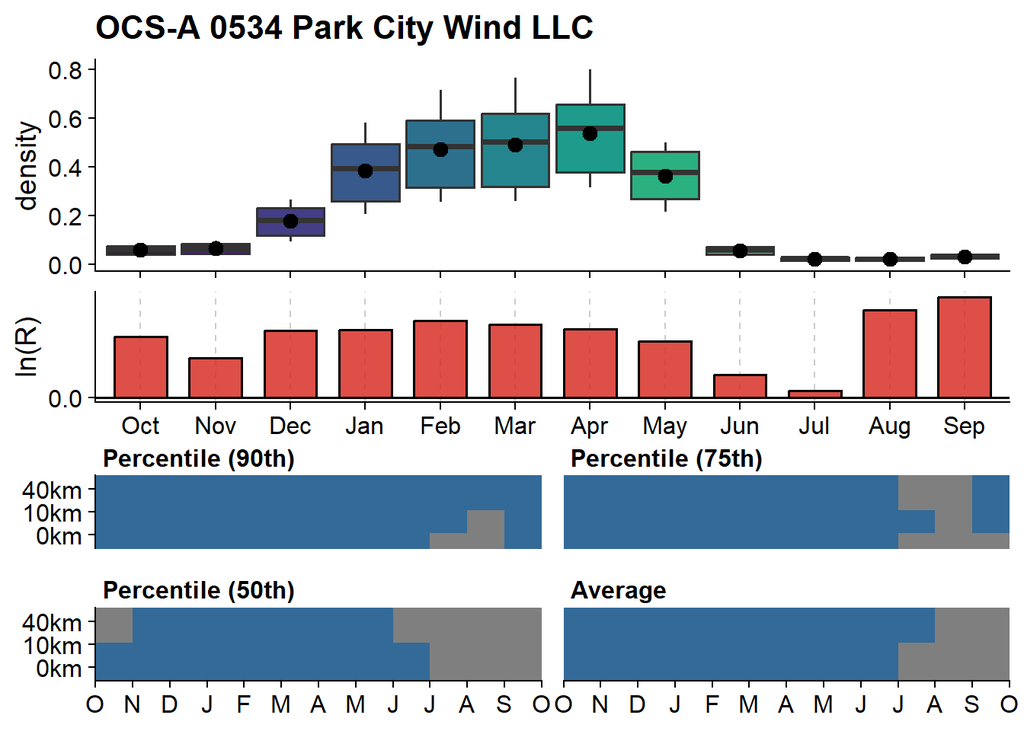

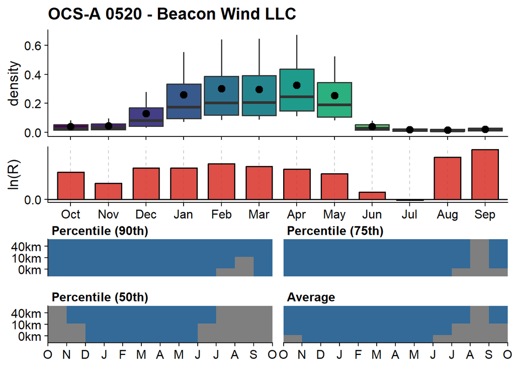

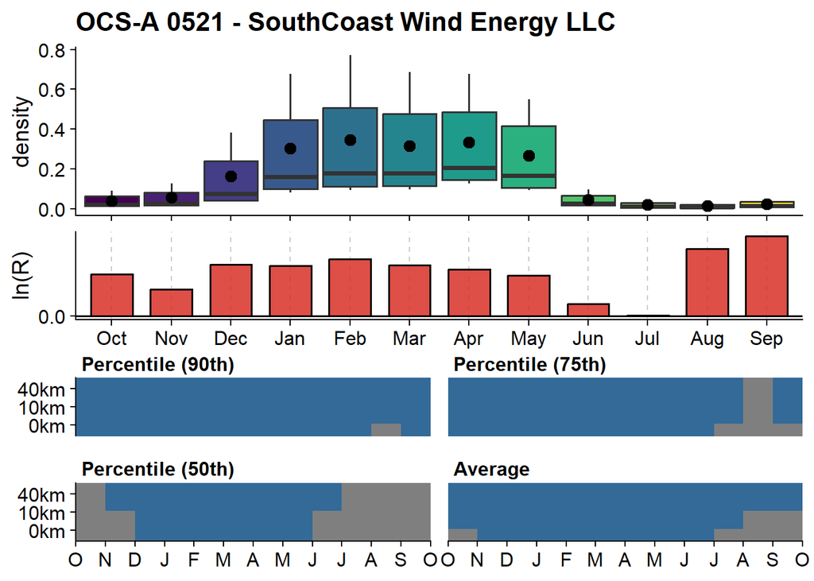

[19 more figures not shown]

# PAM

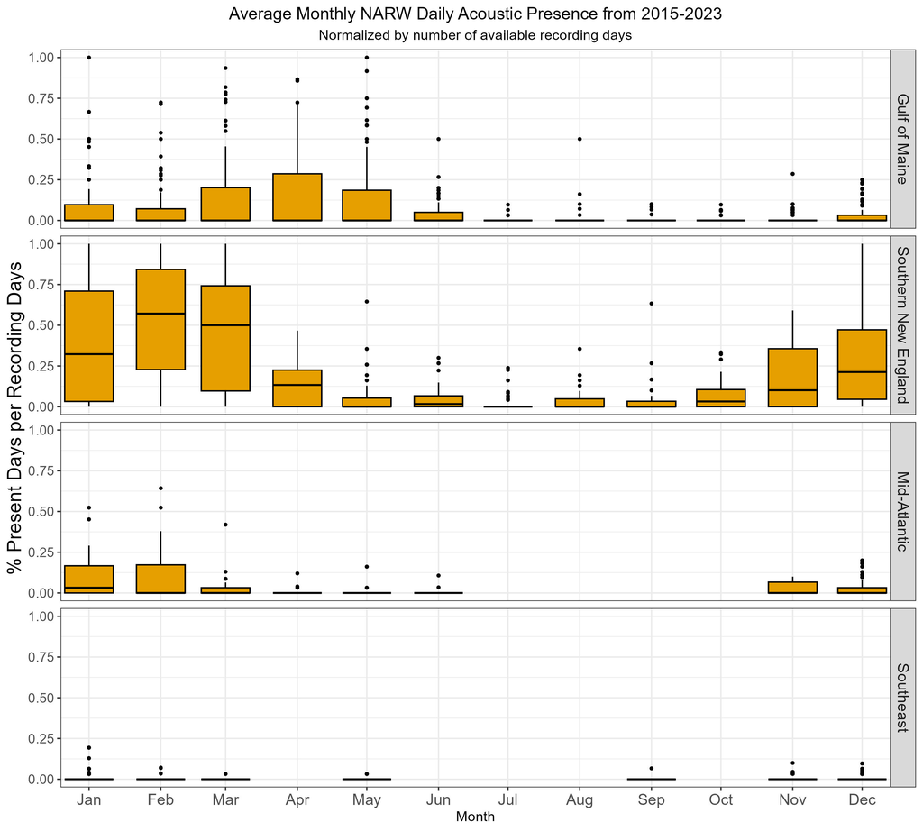

Boxplots showing the average monthly percent of days present for NARWs. The boxplots were drawn such that the lower and upper hinges correspond to the first and third quartiles (the 25th and 75th percentiles). The upper whisker extends from the hinge to the largest value no further than 1.5 * IQR from the hinge (where IQR is the inter-quartile range, or distance between the first and third quartiles). The lower whisker extends from the hinge to the smallest value at most 1.5 * IQR of the hinge. Data beyond the end of the whiskers are called “outlying” points and are plotted individually. The line represents the median.

# Compare with PAM (y-axis scale fixed)

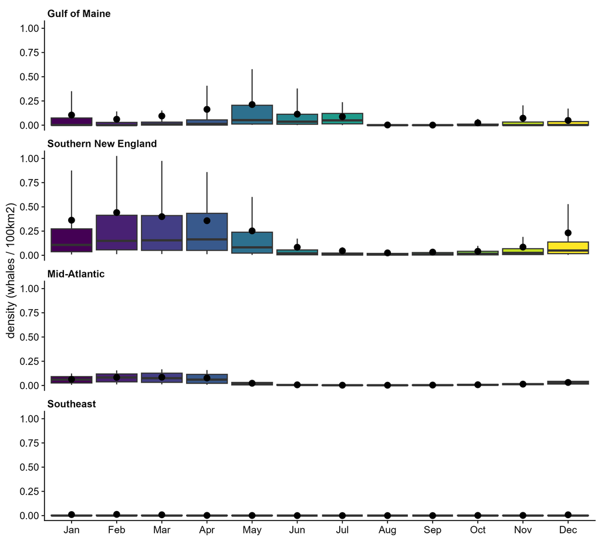

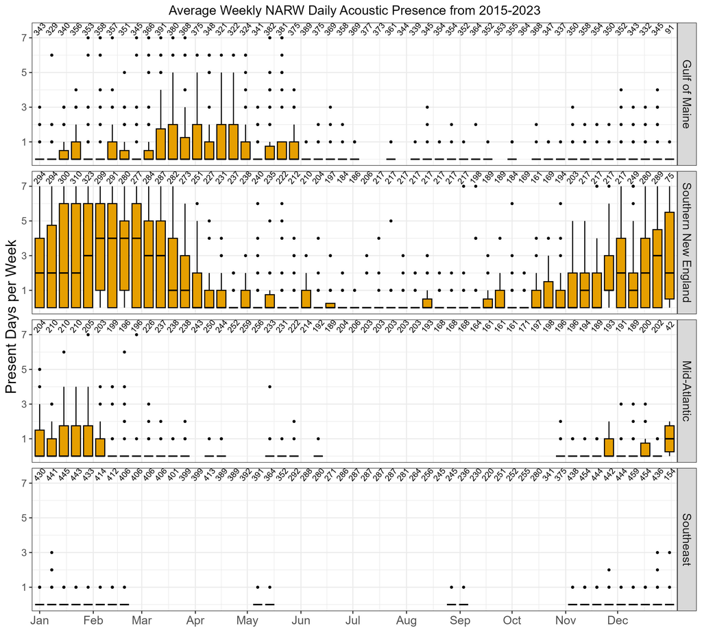

# Compare with PAM (y-axis scale free)

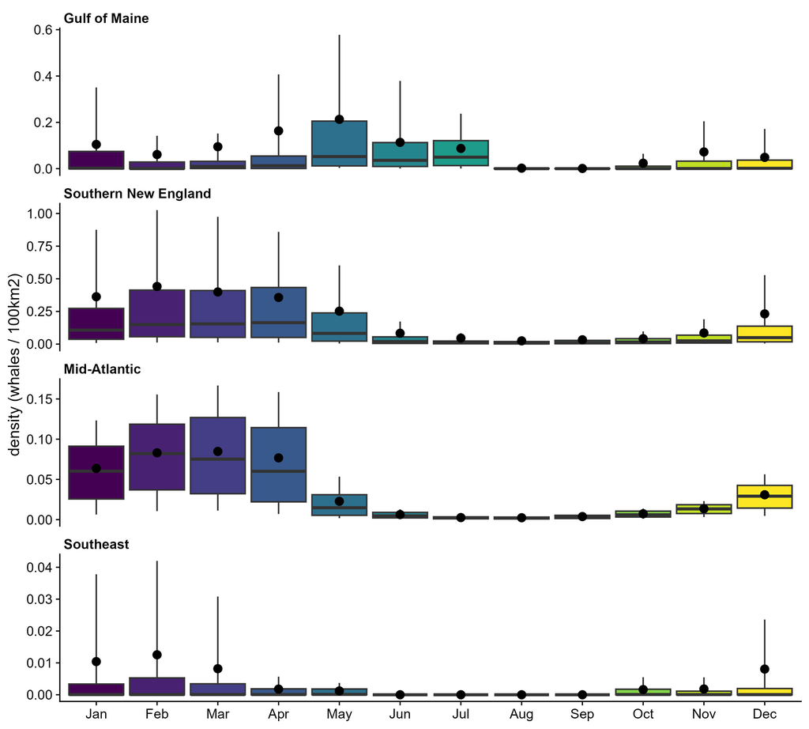

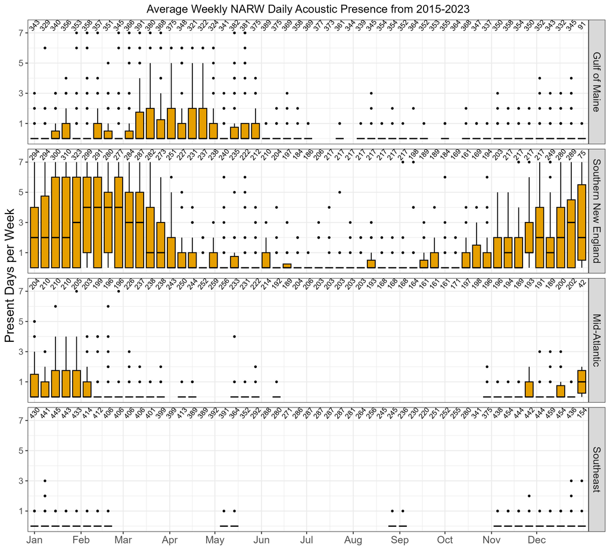

## Metrics relative to region

### Percentile (90th)

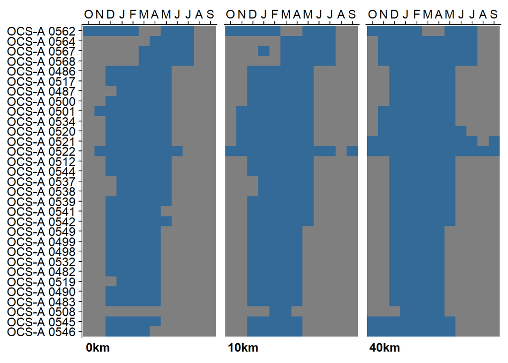

### Percentile (75th)

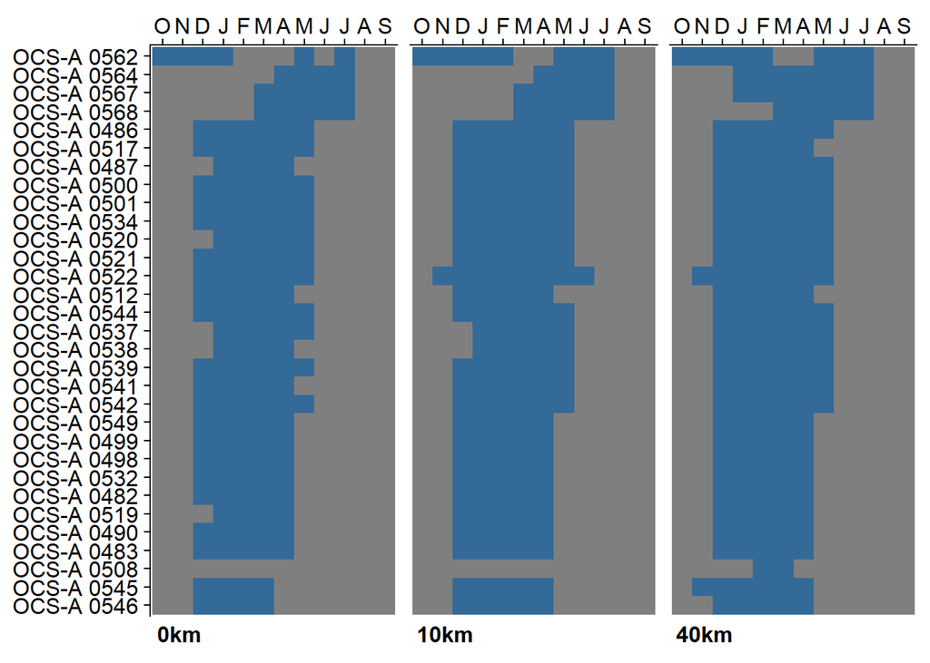

### Percentile (50th)

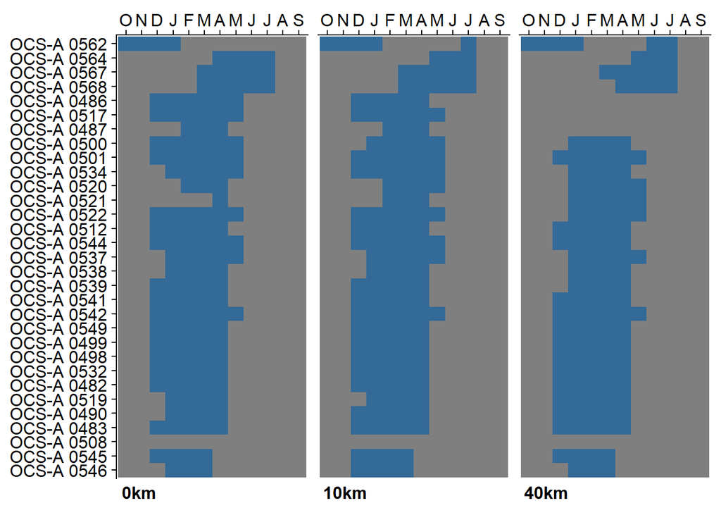

### Average

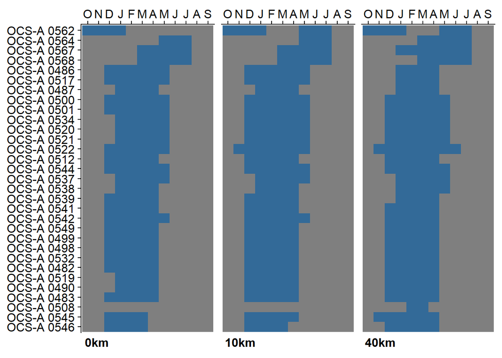

## Metrics relative to coastwide

### Percentile (90th)

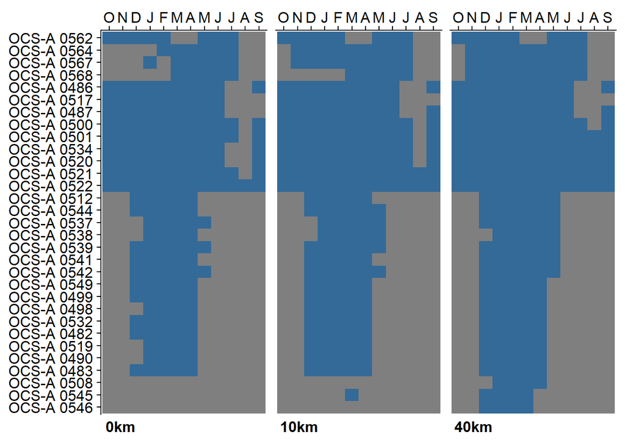

### Percentile (75th)

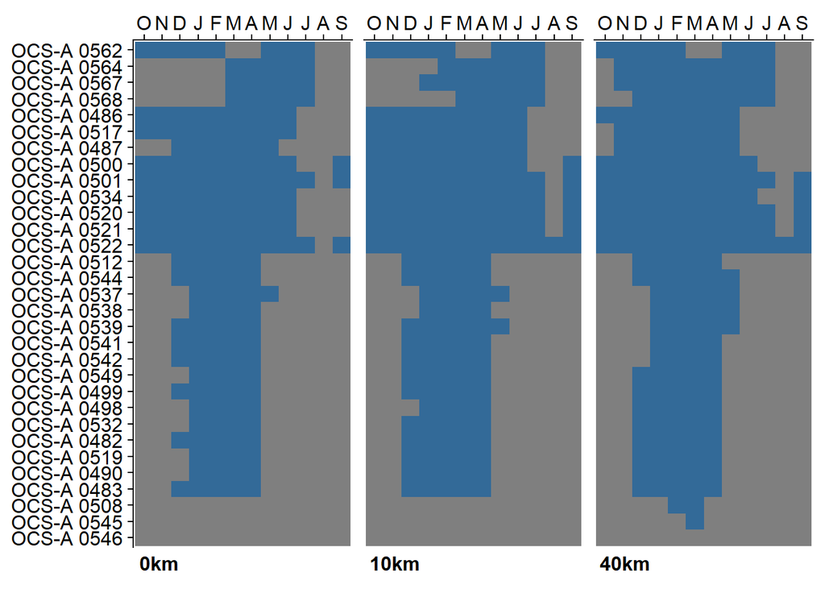

### Percentile (50th)

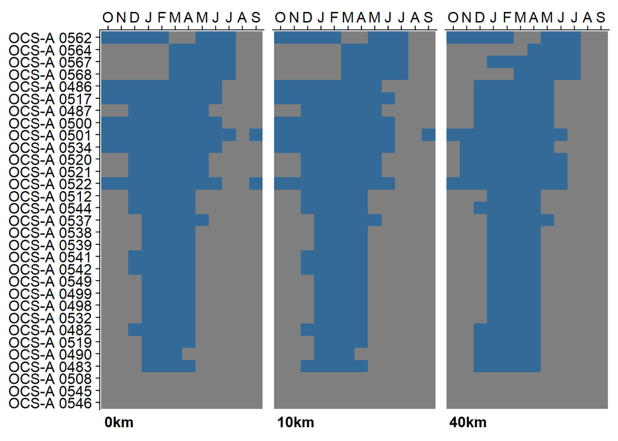

### Average

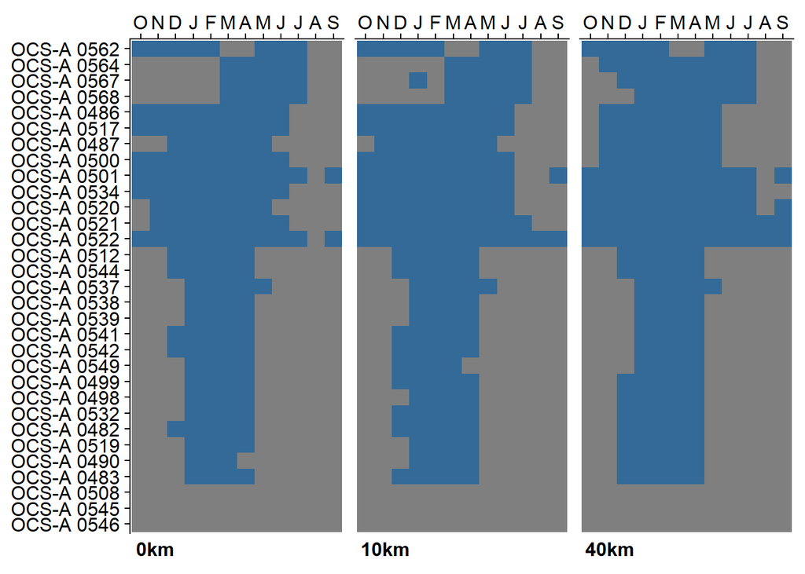

## Median of NARW Density from Lease Areas (and Buffers)

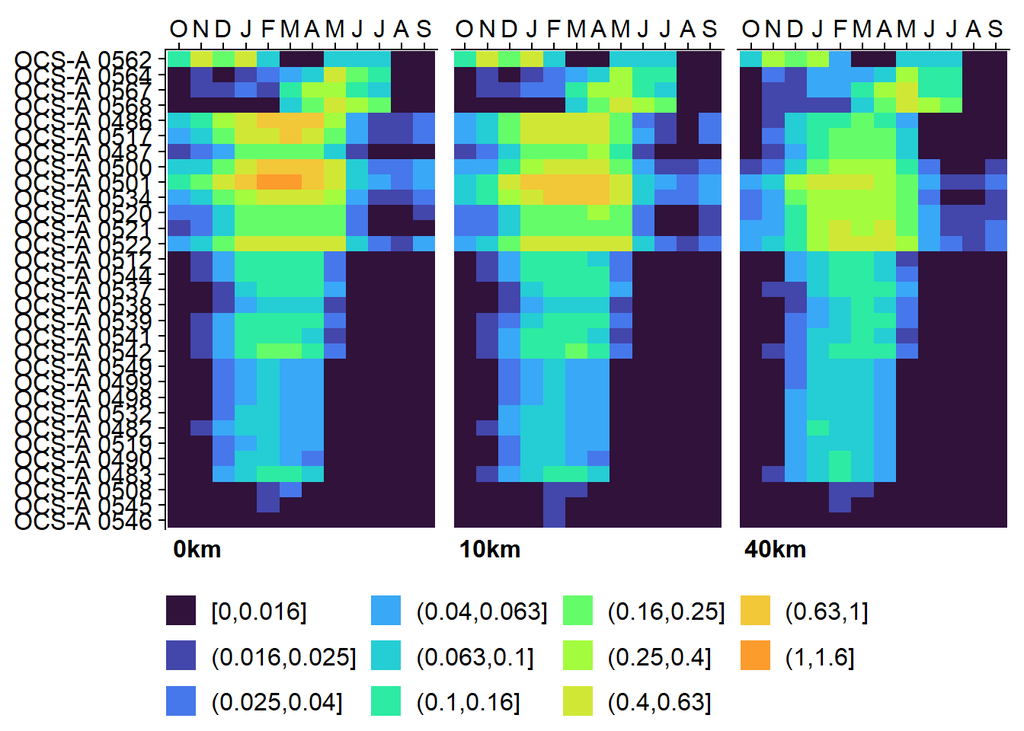